# Statistics with R - Assignment1

Ville Lehtonen

24.4.2020

## Question 1:

##### What was good in the data:

- no cell formatting was used (i.e. colors)
- comments were put in separate columns
- variable names were clear and camelCase was used mostly (although in some columns this was not the case)
- Data was split into different tables and samples and counts tables were connected by the sample value

##### What could be improved:

- The counts data could have been in a ‘long’ format i.e. there should have been a column called ‘sample’ and ‘count’, instead of having multiple samples as separate columns
- The ‘bad data’ (with i.e. missing values) could have been labeled in a new column that would have had just TRUE / FALSE values indicating whether this is good or bad data. This would ease the filtering of data
- in ‘samples’ table, the time columns could have been split into hours and minutes columns so that they would only include numerical values
- in ‘samples’ table, there was a column called ‘duplicate’ that contained french (Oui / Non). Instead it would be simpler if it would contain only a logical TRUE / FALSE value
- Metadata was missing

## Question 2:

Create objects for counts, samples, and communities data

```r
counts <- read_xlsx('lait_caille_data.xlsx',
                    sheet = 'counts',
                    col_names = TRUE)

samples <- read_xlsx('lait_caille_data.xlsx',
                    sheet = 'samples',
                    col_names = TRUE)

communities <- read_xlsx('lait_caille_data.xlsx',
                    sheet = 'communities',
                    col_names = TRUE)
```

## Question 3:

Split counts data and tidy it

```r
# Split counts data into taxonomy and counts objects (both contain rankID)
taxonomy <- select(counts,taxlevel, rankID, taxon)
counts <- select(counts, -taxlevel, -taxon)

# Transform counts object into a tidy format with 3 columns (rankID, sample, count)
counts_tidy <- gather(data = counts,
                      key = sample,
                      value = count,
                      -rankID)
```

## Question 4:

Perform checks

```r
# Gather all unique sample IDs from 'counts' & 'samples'
counts_IDs <- unique(unlist(counts_tidy$sample, " "))
samples_IDs <- samples$sample

# Check that both IDs vectors contain the same objects
print(c("Check that all IDs of counts are in samples:", all(counts_IDs %in% samples_IDs)))
```

```
## [1] "Check that all IDs of counts are in samples:"
## [2] "TRUE"
```

```r
print(c("Check that all IDs of samples are in counts:", all(samples_IDs %in% counts_IDs)))
```

```
## [1] "Check that all IDs of samples are in counts:"
## [2] "TRUE"
```

```r
# Gather unique community names from 'communities' and 'samples'
original_names <- communities$original
samples_communities <- unique(unlist(samples$community, " "))

# Check if all original names are included in communities in 'samples' and vice versa
print(c("Check that all original names are in the communities of samples:", all(original_names %in% samples_communities)))
```

```
## [1] "Check that all original names are in the communities of samples:"
## [2] "TRUE"
```

```r
print(c("Check that all communities of samples are in the original names:", all(samples_communities %in% original_names))) #-> FALSE
```

```
## [1] "Check that all communities of samples are in the original names:"
## [2] "FALSE"
```

```r
# Gather the missing communities (= surplus or have missing values) into a list
missing_communities <- samples_communities[!samples_communities %in% original_names]
```

Comments: It seems that not all communities found in samples are present in the original names

## Question 5:

Filter rows where community is in senegal and taxonomy level is 6

```r
# Add community to 'counts' by sample ID from 'samples'
counts_tidy_merged <- merge(counts_tidy, samples[, c("sample", "community")],
                     by = "sample",
                     all.x = TRUE)

# Add taxlevel to 'counts' by rankID from 'taxonomy'
counts_tidy_merged <- merge(counts_tidy_merged, taxonomy[, c("taxlevel", "rankID")],
                     by = "rankID",
                     all.x = TRUE)

# Filter rows where community is in Senegal and taxonomy level is 6
counts_selected <- counts_tidy_merged %>%
  filter(community %in% communities$original) %>%
  filter(taxlevel == 6)
```

## Question 6:

Calculate fractions of counts for each sample per genus

```r
# Calculate total counts per sample and the fraction of counts in each sample per genus
counts_selected <- counts_selected %>%
  group_by(sample) %>%
  mutate(fraction = count / sum(count), total_count = sum(count)) %>%
  ungroup()
```

## Question 7:

Calculate the total LAB fraction for each sample

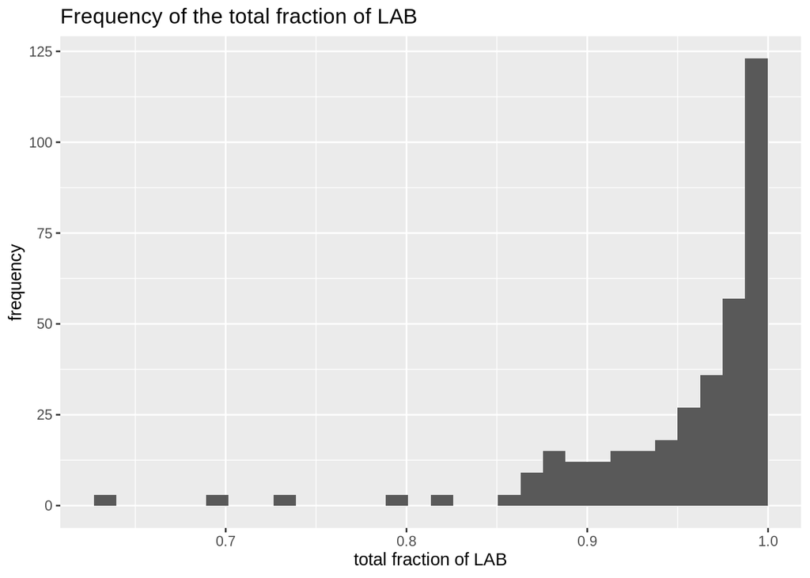

Figure 1. Frequency of the total fractions of LAB

```r
#Merge the taxon column to data
counts_selected <- merge(counts_selected,
                         taxonomy[, c("taxon", "rankID")],
                         by = 'rankID',
                         all.x = TRUE)

counts_updated <- counts_selected %>%
  group_by(sample) %>%
  filter(taxon=='Lactococcus'| taxon=='Lactobacillus'| taxon=='Streptococcus') %>%
  mutate(LAB_total_fraction = sum(count) / total_count) %>%
  ungroup()

#Histogram of the total fraction of these LAB
counts_updated %>%
  group_by(sample) %>%
  ggplot(mapping = aes(x = LAB_total_fraction)) +
  geom_histogram() +
  labs(x = "total fraction of LAB", y = "frequency", title = "Frequency of the total fraction of LAB")
```

## Question 8:

Summarise the number of samples per dominant LAB

```r
# Make an object in which the dominant LAB genus is listed per sample
# If the total LAB is less than 90% then set the value for dominant LAB genus to “(none)”
counts_updated <- counts_updated %>%
  group_by(sample) %>%
  mutate(dominant_LAB_genus = ifelse(LAB_total_fraction > 0.9, taxon[which.max(fraction)], "none")) %>%
  ungroup()

# Print a table that summarizes the total number of samples per dominant LAB.
summary_tibble <- counts_updated %>%
  group_by(sample, dominant_LAB_genus) %>%
  summarise(count = n()) %>%
  group_by(dominant_LAB_genus) %>%
  summarise(count = n()) %>%
  ungroup()

# Rename columns
summary_tibble2 <- summary_tibble
summary_tibble2 <- rename(summary_tibble2, "Dominant LAB genus" = dominant_LAB_genus)
summary_tibble2 <- rename(summary_tibble2, "#Samples" = count)

summary_tibble2 %>%
  knitr::kable(format="html", caption="Table 1. Number of samples in each dominant LAB genus.") %>%
  kableExtra::kable_styling()
```

Table 1. Number of samples in each dominant LAB genus.

| Dominant LAB genus | #Samples |
| --- | --- |
| Lactobacillus | 27 |
| none | 18 |
| Streptococcus | 74 |

## Question 9:

Summarise the fraction of contaminated samples by the dominant LABs

```r
# Get genera file
#current_dir <- dirname(rstudioapi::getActiveDocumentContext()$path)
#data_file_path <- paste(current_dir, '/data', sep = "")
#setwd(data_file_path)

genera <- read.csv('colon_genera.tab',
                   header = TRUE,
                   sep = '',
                   comment.char = '#')

genuses <- genera$genus

# Compute whether a sample is heavily contaminated (i.e. total fraction of colon > 0.1)
counts_contaminated <- counts_selected %>%
  group_by(sample) %>%
  filter(taxon %in% genuses) %>%
  mutate(fraction_contaminated = sum(count) / total_count,
         contaminated = ifelse(fraction_contaminated > 0.01, TRUE, FALSE)) %>%
  ungroup()

# Add the contaminated column to 'counts'
counts_contaminated_updated <- merge(counts_updated,
                                     counts_contaminated[, c("sample", "fraction_contaminated", "contaminated")],
                                     all.x = TRUE)

#Filter out duplicate sample rows
counts_contaminated_updated2 <- counts_contaminated_updated[!duplicated(counts_contaminated_updated$sample), ]

# Calculate the amount of contaminated samples
contaminated_summary <- counts_contaminated_updated2 %>%
  group_by(dominant_LAB_genus, contaminated) %>%
  filter(contaminated == TRUE) %>%
  summarise(count = n()) %>%
  ungroup()

# Add the number and fraction of contaminated samples to each group
summary_tibble$number_contaminated <- contaminated_summary$count
summary_tibble$fraction_contaminated <- summary_tibble$number_contaminated / summary_tibble$count

# Rename columns
summary_tibble <- rename(summary_tibble, "Dominant LAB genus" = dominant_LAB_genus)
summary_tibble <- rename(summary_tibble, "#Samples" = count)
summary_tibble <- rename(summary_tibble, "#contaminated" = number_contaminated)
summary_tibble <- rename(summary_tibble, "Fraction contaminated" = fraction_contaminated)

#print(summary_tibble)
summary_tibble %>%
  knitr::kable(format="html", caption="Table 2. Number of samples and contaminated samples and their fraction of all samples in each dominant LAB genus.") %>%
  kableExtra::kable_styling()
```

Table 2. Number of samples and contaminated samples and their fraction of all samples in each dominant LAB genus.

| Dominant LAB genus | #Samples | #contaminated | Fraction contaminated |
| --- | --- | --- | --- |
| Lactobacillus | 27 | 3 | 0.1111111 |
| none | 18 | 9 | 0.5000000 |
| Streptococcus | 74 | 7 | 0.0945946 |

## Question 10:

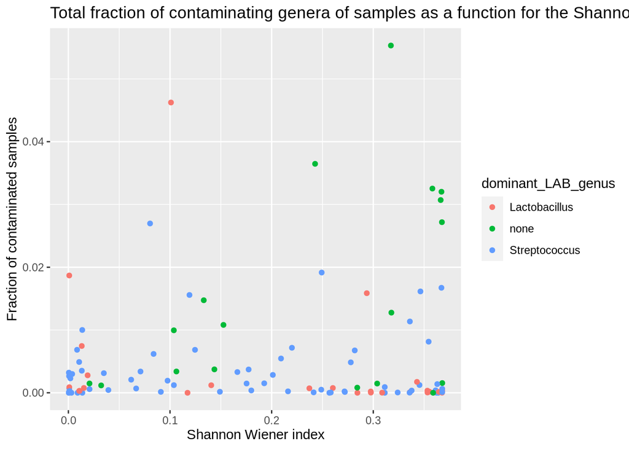

Figure 2. Total fraction of contaminating genera of samples as a function for the Shannon-Wiener diversity index

```r
# graph displaying the total fraction of contaminating genera of samples as a function fo the Shannon-Wiener diversity index

counts_per_sample <- counts_contaminated_updated2 %>%
  group_by(sample) %>%
  mutate(shannon_wiener = -sum(fraction * log(fraction))) %>%
  ungroup()

counts_per_sample %>%
  ggplot(mapping = aes(x = shannon_wiener,
                       y = fraction_contaminated,
                       color = dominant_LAB_genus)) +
  geom_point() +
  labs(x = "Shannon Wiener index", y = "Fraction of contaminated samples", title = "Total fraction of contaminating genera of samples as a function for the Shannon-Wiener diversity index")
```

#### comments:

- The above plot seems to have very low Shannon Wiener values so I’ve most likely made a mistake at some point. I’m aware of this and I would have fixed the issue if I wouldn’t have ran out of time.

## Question 11

```r
# t-test to investigate whether the total fraction of contamination differs significantly between samples that do and don’t have a dominant LAB
samples_dominant_LAB <- counts_per_sample[counts_per_sample$dominant_LAB_genus != "none", ]
samples_none <- counts_per_sample[counts_per_sample$dominant_LAB_genus == "none", ]

t_result <- t.test(samples_dominant_LAB$fraction_contaminated, samples_none$fraction_contaminated)

print(t_result)
```

```
##
##  Welch Two Sample t-test
##
## data:  samples_dominant_LAB$fraction_contaminated and samples_none$fraction_contaminated
## t = -3.1027, df = 18.002, p-value = 0.006143
## alternative hypothesis: true difference in means is not equal to 0
## 95 percent confidence interval:
##  -0.020355600 -0.003918746
## sample estimates:
##   mean of x   mean of y
## 0.003203092 0.015340265
```

#### Conclusion:

t-test gives a low p-value, indicating that the null hypothesis should be rejected. Thus, the groups seem to differ in terms of the fraction of contaminated samples. In other words, it seems that there is a correlation between not having a dominant LAB genus and having more contaminated samples.

## Question 12

```r
#table that lists the dominant LAB categories per village (community)
village_table <- counts_per_sample %>%
  group_by(community, dominant_LAB_genus) %>%
  summarise(count = n())

village_table_new <- spread(data = village_table, dominant_LAB_genus, count)

village_table_new %>%
  knitr::kable(format="html", caption="Table 3. Dominant LAB categories per village") %>%
  kableExtra::kable_styling()
```

Table 3. Dominant LAB categories per village

| community | Lactobacillus | none | Streptococcus |
| --- | --- | --- | --- |
| Didiéry | 1 | 1 | 8 |
| Gaya | 8 | 2 | 16 |
| Guilado | 5 | 3 | 15 |
| Keur Mbaye Peul | 3 | 8 | 8 |
| Medina Cheikh Mountaga | 9 | 1 | 12 |
| Pathé Badio | 1 | 3 | 15 |